# Getting Started with ml

```r
library(ml)
```

## Why another ML package?

Most machine learning code leaks information from test data into training without anyone noticing. Preprocessing on the full dataset, repeatedly evaluating on a single held-out set, using the same data to select hyperparameters and report final performance – each of these inflates reported accuracy and produces models that disappoint in production.

Chapter 7 of Hastie, Tibshirani, and Friedman (2009) prescribes a strict separation: a **validation** set for iterating on model choices, and a **test** set touched exactly once for the final generalization estimate. The `ml` package enforces that separation at the API level.

The workflow has four verbs:

1. **Split** the data into train, validation, and test.
2. **Fit** a model on training data.
3. **Evaluate** on validation data – repeat as often as you like.
4. **Assess** on test data – once, when you are done.

Calling `ml_evaluate()` ten times is fine. Calling `ml_assess()` ten times defeats the purpose. The API makes the distinction explicit.

## Profile

Before modeling, understand what you have:

```r
prof <- ml_profile(iris, "Species")
prof
```

```
#> -- Profile [classification] --
#>   rows    : 150
#>   columns : 5
#>   target  : Species
#>   warnings:
#>     ! Small dataset (150 rows). ~90 train, ~30 test after split.
```

## Split

Three-way split: 60% train, 20% validation, 20% test. Classification targets are stratified automatically.

```r
s <- ml_split(iris, "Species", seed = 42)
s
```

```
#> -- Split --
#>   train : 90 rows (60%)
#>   valid : 30 rows (20%)
#>   test  : 30 rows (20%)
#>   dev   : 120 rows (train + valid combined)
```

The `$dev` property merges train and validation for final retraining before deployment. Use it only after you have settled on an algorithm and hyperparameters.

## Screen

```r
lb <- ml_screen(s, "Species", seed = 42)
lb
```

```
#> -- Leaderboard [classification * 7] --
#>      algorithm accuracy f1_weighted f1_macro precision_weighted precision_macro
#>    elastic_net   0.9333      0.9333   0.9333             0.9333          0.9333
#>    naive_bayes   0.9333      0.9327   0.9327             0.9444          0.9444
#>  decision_tree   0.9000      0.8997   0.8997             0.9024          0.9024
#>            knn   0.9000      0.8997   0.8997             0.9024          0.9024
#>       logistic   0.9000      0.8997   0.8997             0.9024          0.9024
#>  random_forest   0.9000      0.8997   0.8997             0.9024          0.9024
#>        xgboost   0.3000      0.2873   0.2873             0.3116          0.3116
#>  recall_weighted recall_macro  time
#>           0.9333       0.9333 0.019
#>           0.9333       0.9333 0.003
#>           0.9000       0.9000 0.013
#>           0.9000       0.9000 0.002
#>           0.9000       0.9000 0.004
#>           0.9000       0.9000 0.027
#>           0.3000       0.3000 0.031
```

## Fit and evaluate

Train a model and check it on the validation set. You can call `ml_evaluate()` as many times as you want – that is the whole point of having a separate validation partition.

```r
model <- ml_fit(s$train, "Species", algorithm = "logistic", seed = 42)
model
```

```
#> -- Model [logistic * classification] --
#>   features : 4
#>   rows     : 90
#>   target   : Species
#>   seed     : 42
#>   hash     : 00001f3b
#>   (0.00s)
```

```r
metrics <- ml_evaluate(model, s$valid)
metrics
```

```
#> -- Metrics [classification] --
#>   accuracy:              0.9000   precision_macro:       0.9024
#>   f1_weighted:           0.8997   recall_weighted:       0.9000
#>   f1_macro:              0.8997   recall_macro:          0.9000
#>   precision_weighted:    0.9024   :
#>   (0.00s)
```

## Visual diagnostics

`ml_plot()` produces base R graphics with no extra dependencies.

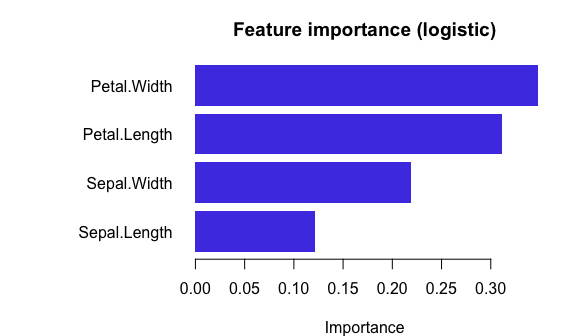

```r
ml_plot(model, kind = "importance")
```

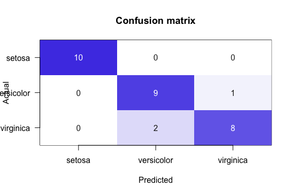

```r
ml_plot(model, data = s$valid, kind = "confusion")
```

## Explain

Feature importances normalized to sum to 1.0. For logistic regression these are absolute coefficient magnitudes; for tree-based models, impurity-based importances.

```r
ml_explain(model)
```

```
#> -- Explain [logistic] --
#>   Petal.Width          ██████████ 0.348
#>   Petal.Length         █████████ 0.312
#>   Sepal.Width          ███████ 0.219
#>   Sepal.Length         ████ 0.122
```

## Validate

Gate your model before the final assessment. Define thresholds that must be met. If any rule fails, `$passed` is `FALSE` and the report shows which rules were violated.

```r
gate <- ml_validate(model,
                    test  = s$test,
                    rules = list(accuracy = ">0.80"))
gate
```

```
#> -- Validate [PASSED] --
```

## Assess (once)

The test set is your final exam. Call `ml_assess()` exactly once, when you are done experimenting. The result is your honest generalization estimate.

```r
verdict <- ml_assess(model, test = s$test)
verdict
```

```
#> -- Evidence [classification] --
#>   accuracy:              0.9667
#>   f1_weighted:           0.9666
#>   f1_macro:              0.9666
#>   precision_weighted:    0.9697
#>   precision_macro:       0.9697
#>   recall_weighted:       0.9667
#>   recall_macro:          0.9667
#>   (0.00s)
```

## Drift detection

When new data arrives, check whether the input distribution has shifted. No labels required – this uses per-feature statistical tests.

```r
# Simulate drift: shift one feature by 2 units
drifted <- s$test
drifted$Sepal.Length <- drifted$Sepal.Length + 2

result <- ml_drift(reference = s$train, new = drifted, target = "Species")
result
```

```
#> -- Drift [DRIFT DETECTED] --
#>   severity  : medium
#>   reference : 90 rows
#>   new       : 30 rows
#>   shifted   : 1/4 features
#>   features  : Sepal.Length
```

## Save and load

Models serialize to a compact `.mlr` format:

```r
path <- file.path(tempdir(), "iris_model.mlr")
ml_save(model, path)
loaded <- ml_load(path)
identical(predict(model, s$valid), predict(loaded, s$valid))
```

```
#> [1] TRUE
```

## Two API styles

Every function is available both as `ml_verb()` (idiomatic R) and as `ml$verb()` (module style, mirrors the Python package):

```r
m2 <- ml$fit(s$train, "Species", algorithm = "logistic", seed = 42)
identical(predict(model, s$valid), predict(m2, s$valid))
```

```
#> [1] TRUE
```

## Regression

The same workflow applies to continuous targets. The task is detected automatically from the target column type.

```r
s2    <- ml_split(mtcars, "mpg", seed = 42)
m_reg <- ml_fit(s2$train, "mpg", seed = 42)
ml_evaluate(m_reg, s2$valid)
```

```
#> -- Metrics [regression] --
#>   rmse:                  3.4525
#>   mae:                   2.6034
#>   r2:                    0.5269
#>   (0.00s)
```

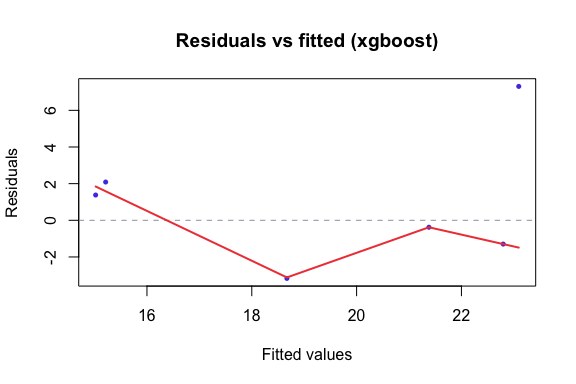

```r
ml_plot(m_reg, data = s2$valid, kind = "residual")
```

## Available algorithms

```r
ml_algorithms()
```

```
#>            algorithm classification regression optional_dep installed engine
#> 1           adaboost           TRUE      FALSE     (native)      TRUE      r
#> 2      decision_tree           TRUE       TRUE        rpart      TRUE      r
#> 3        elastic_net          FALSE       TRUE       glmnet      TRUE      r
#> 4        extra_trees           TRUE       TRUE     (native)      TRUE      r
#> 5  gradient_boosting           TRUE       TRUE     (native)      TRUE      r
#> 6       histgradient           TRUE       TRUE     (native)      TRUE      r
#> 7                knn           TRUE       TRUE         kknn      TRUE      r
#> 8             linear          FALSE       TRUE       glmnet      TRUE      r
#> 9           logistic           TRUE      FALSE     (native)      TRUE      r
#> 10       naive_bayes           TRUE      FALSE   naivebayes      TRUE      r
#> 11     random_forest           TRUE       TRUE       ranger      TRUE      r
#> 12               svm           TRUE       TRUE        e1071      TRUE      r
#> 13           xgboost           TRUE       TRUE      xgboost      TRUE      r
```

## References

Hastie, T., Tibshirani, R. and Friedman, J. (2009). *The Elements of Statistical Learning*, 2nd edition, Springer. Chapter 7: Model Assessment and Selection.